# Data Analysis Rapport: Slaapefficiëntie

https://www.kaggle.com/datasets/equilibriumm/sleep-efficiency

# Probleemstelling

‘Het doel van dit onderzoek is om de slaapkwaliteit van elke proefpersoon te meten en de relaties tussen verschillende factoren die de slaapefficiëntie kunnen beïnvloeden.’

# Vraagstellingen

-Is er een duidelijk verschil tussen geslacht en leeftijd dat de slaapefficiëntie kan beïnvloeden?

-Wat is de voorkeurstijd om te gaan slapen/ontwaaktijd tussen de deelnemers?

-Beïnvloeden andere stoffen (bijv. alcohol, koffie, rokers...) slaappatronen?

-Heeft de frequentie van het sporten invloed op de efficiëntie van de diepe slaap?

-Beïnvloedt het aantal keren dat men wakker wordt de slaapefficiëntie?

# Waarom heb ik deze onderwerp gekozen?

Ik heb dit onderwerp gekozen omdat ik graag iets meer wil weten over het slaappatroon van verschillende personen en dit wil vergelijken met mijn eigen slaapschema. Ik wil weten of mijn slaapschema correct is of niet, of dat ik mijn slaapefficiëntie moet verbeteren door de dataset te analyseren en elke variabele te vergelijken met een resultaat of percentage van de verschillende slaapkwaliteiten, bijvoorbeeld: slaapduur/efficiëntie en het percentage diepe en lichte slaap.

Nadat ik het onderzoek had afgerond, leerde ik veel over hoe slaappatronen werken en hoe deze gegevens je een goed inzicht bieden over de variabelen die elke slaapkwaliteit kunnen veranderen. Zoals bijvoorbeeld dat het aantal keren dat je wakker wordt direct invloed heeft op je slaapefficiëntie en de kwaliteit van je slaap verandert. Met dit soort bevindingen kan ik mijn slaapschema beter plannen en mijn slaap verbeteren door enkele variabelen te veranderen die mijn slaap kunnen bevorderen.

# Import packages

Door de bibliotheken te importeren krijgt u een bepaald pakket aan functies die je kunt gebruiken om de gegevens op te schonen, EDA te maken en de gegevens te visualiseren.

Elke bibliotheek heeft verschillende functies en bevat meerdere variabelen en verschillende voorstellen:

- NumPy is een essentiële bibliotheek voor wetenschappelijke berekeningen in Python.Het biedt ondersteuning voor grote, multidimensionale arrays en matrices.
- Pandas is een bibliotheek voor data manipulatie en analyse. Het biedt datastructuren en operaties voor het manipuleren van numerieke tabellen en tijdreeksen.
- Seaborn is een Python visualisatiebibliotheek gebaseerd op matplotlib.Het biedt een high-level interface voor het tekenen van aantrekkelijke en informatieve statistische grafieken.
- Matplotlib is een uitgebreide bibliotheek voor het creëren van statische, interactieve en geanimeerde visualisaties in Python. Deze import statement haalt de SimpleImputer klasse uit de sklearn-bibliotheek.
- SimpleImputer is een handige tool voor het omgaan met ontbrekende waarden in datasets.

```python
#Importeer de benodigde packages
import numpy as np
from sklearn.linear_model import LinearRegression
import pandas as pd
import seaborn as sns
import matplotlib.pyplot as plt
import statsmodels.api as sm
from sklearn.impute import SimpleImputer


#Om alle kolommen en rijen volledig te geven
#pd.set_option('display_max_columns', None)
#pd.set_option('display_max_rows', None)
```

Deze commando's zijn uitgecommentarieerd en zouden, indien actief, instellen dat Pandas alle kolommen en rijen toont wanneer DataFrames worden weergegeven.

# Load dataset

Deze regel code laadt een CSV-bestand in een DataFrame. Dit wordt gedaan met behulp van de `read_csv` functie van de pandas bibliotheek, die hier is geïmporteerd onder de alias 'pd'. De functie `read_csv` leest een komma-gescheiden waarde (CSV) bestand en converteert het naar een DataFrame, wat een 2-dimensionale gelabelde datastructuur is met kolommen van potentieel verschillende typen.

```python
# De geladen data wordt opgeslagen in de variabele 'sleep', waarmee verder gewerkt kan worden voor analyse of verwerking.
sleep = pd.read_csv("C:\\Users\\kaile\\OneDrive - Office 365 Fontys\\S3\\Sleep_Efficiency.csv")
sleep
```

|  | ID | Age | Gender | Bedtime | Wakeup time | Sleep duration | Sleep efficiency | REM sleep percentage | Deep sleep percentage | Light sleep percentage | Awakenings | Caffeine consumption | Alcohol consumption | Smoking status | Exercise frequency |
| --- | --- | --- | --- | --- | --- | --- | --- | --- | --- | --- | --- | --- | --- | --- | --- |
| 0 | 1 | 65 | Female | 2021-03-06 01:00:00 | 2021-03-06 07:00:00 | 6.0 | 0.88 | 18 | 70 | 12 | 0.0 | 0.0 | 0.0 | Yes | 3.0 |
| 1 | 2 | 69 | Male | 2021-12-05 02:00:00 | 2021-12-05 09:00:00 | 7.0 | 0.66 | 19 | 28 | 53 | 3.0 | 0.0 | 3.0 | Yes | 3.0 |
| 2 | 3 | 40 | Female | 2021-05-25 21:30:00 | 2021-05-25 05:30:00 | 8.0 | 0.89 | 20 | 70 | 10 | 1.0 | 0.0 | 0.0 | No | 3.0 |
| 3 | 4 | 40 | Female | 2021-11-03 02:30:00 | 2021-11-03 08:30:00 | 6.0 | 0.51 | 23 | 25 | 52 | 3.0 | 50.0 | 5.0 | Yes | 1.0 |
| 4 | 5 | 57 | Male | 2021-03-13 01:00:00 | 2021-03-13 09:00:00 | 8.0 | 0.76 | 27 | 55 | 18 | 3.0 | 0.0 | 3.0 | No | 3.0 |
| ... | ... | ... | ... | ... | ... | ... | ... | ... | ... | ... | ... | ... | ... | ... | ... |
| 447 | 448 | 27 | Female | 2021-11-13 22:00:00 | 2021-11-13 05:30:00 | 7.5 | 0.91 | 22 | 57 | 21 | 0.0 | 0.0 | 0.0 | No | 5.0 |
| 448 | 449 | 52 | Male | 2021-03-31 21:00:00 | 2021-03-31 03:00:00 | 6.0 | 0.74 | 28 | 57 | 15 | 4.0 | 25.0 | 0.0 | No | 3.0 |
| 449 | 450 | 40 | Female | 2021-09-07 23:00:00 | 2021-09-07 07:30:00 | 8.5 | 0.55 | 20 | 32 | 48 | 1.0 | NaN | 3.0 | Yes | 0.0 |
| 450 | 451 | 45 | Male | 2021-07-29 21:00:00 | 2021-07-29 04:00:00 | 7.0 | 0.76 | 18 | 72 | 10 | 3.0 | 0.0 | 0.0 | No | 3.0 |
| 451 | 452 | 18 | Male | 2021-03-17 02:30:00 | 2021-03-17 10:00:00 | 7.5 | 0.63 | 22 | 23 | 55 | 1.0 | 50.0 | 0.0 | No | 1.0 |

452 rows × 15 columns

# Data informatie

Deze dataset bevat informatie over een groep proefpersonen en hun slaappatroon. Elke proefpersoon wordt geïdentificeerd door:

-ID = een unieke identificator voor elke proefpersoon

-Leeftijd = de leeftijd van elke deelnemer

-Geslacht = man of vrouw -Bedtijd = Het moment waarop de deelnemer dagelijks naar bed gaat

-Wektijd = het tijdstip waarop de proefpersoon elke ochtend wakker wordt

-Slaapduur = de totale tijd dat de proefpersoon heeft geslapen (in uren).

-REM-slaappercentage = het percentage van de totale slaaptijd dat wordt doorgebracht in REM-slaap

-Diepe slaappercentage = het percentage van de totale slaaptijd dat in diepe slaap is doorgebracht

-Percentage lichte slaap = het percentage van de totale slaaptijd dat in lichte slaap wordt doorgebracht

-Ontwaken = het aantal keren dat de proefpersoon 's nachts wakker wordt

-Cafeïneconsumptie = de hoeveelheid cafeïne die in de 24 uur vóór het slapengaan is geconsumeerd (in mg)

-Alcoholconsumptie = de hoeveelheid alcohol die is geconsumeerd in de 24 uur vóór het slapengaan (in oz)

-Rookstatus = of de proefpersoon wel of niet rookt

-Beweegfrequentie = het aantal keren dat de proefpersoon wekelijks sport

-Hiermee kunnen we de doelvariabele bepalen, namelijk:

-Slaapefficiëntie = een maatstaf voor de hoeveelheid tijd die in bed wordt doorgebracht met slapen

# Wat betekent REM-slaap?

REM-slaap is de laatste slaapfase voordat de cyclus opnieuw begint. Je eerste REM-cyclus van de nacht begint ongeveer 90 minuten nadat je in slaap valt en herhaalt zich elke 90 minuten. In tegenstelling tot de stadia 3 en 4 lijken je ademhaling, hartslag en bloeddruk op de niveaus die je normaal ervaart als je wakker bent. Men gelooft dat REM-slaap essentieel is voor cognitieve functies zoals geheugen, leren en creativiteit.

# Wat betekent Lichte Slaap?

Lichte slaap is de initiële en minder herstellende fase van de slaapcyclus, bestaande uit fase 1 en 2. Het omvat de vertraging van hersenactiviteit, hartslag en lichaamstemperatuur, wat de basis legt voor diepere slaap. Deze fase faciliteert mentale en fysieke ontspanning, verwerking van herinneringen en regulatie van de stofwisseling.

# Wat betekent Diepe Slaap?

Diepe slaap verwijst naar de derde en vierde fase van de slaapcyclus, gekenmerkt door trage hersengolven, de zogenaamde delta-golven. Deze fase is cruciaal voor fysiek herstel, versterking van het immuunsysteem en de afgifte van groeihormoon, die essentieel zijn voor groei en ontwikkeling. Diepe slaap helpt bij de consolidatie van het geheugen en het herstel van energie.

# EDA (Exploratory Data Analysis)

Deze regel code hernoemt de kolommen van het 'sleep' DataFrame door het gebruik van de `rename` methode. De parameter `columns` krijgt een dictionary waar de sleutels de oude kolomnamen zijn en de waarden de nieuwe kolomnamen. Door de parameter `inplace=True` te zetten, worden de wijzigingen direct in het bestaande DataFrame aangebracht zonder een kopie terug te geven. Dit is handig om de data meer programmeerbaar en consistenter te maken, bijvoorbeeld door alle kolomnamen naar kleine letters te converteren of door spaties en speciale tekens te verwijderen. Het hernoemen van de kolommen verbetert ook de leesbaarheid en toegankelijkheid van de dataset, vooral wanneer deze gebruikt wordt voor verdere data analyse en visualisatie.

```python
sleep.rename(columns = {"Age": "age", "Gender": "gender", "Bedtime": "bedtime",'Wakeup time':'wakeup_time', 'Sleep duration':'sleep_duration ',"Sleep efficiency":"sleep_efficiency",
                     "REM sleep percentage":"REM_sleep_perc","Deep sleep percentage":"deep_sleep_perc",
                     "Light sleep percentage":"light_sleep_perc","Awakenings": "awakenings", "Caffeine consumption":"caffeine_consumption",
                     "Alcohol consumption":"alcohol_consumption","Smoking status":"smoking_status","Exercise frequency":"exercise_frequency"}, inplace = True)
```

Deze functie geeft een overzicht van de DataFrame inclusief het aantal niet-null waarden en het datatypen van elke kolom. Dit is nuttig om de structuur van de data snel te begrijpen, inclusief hoeveel data punten er zijn en hoeveel ontbrekende waarden.

```python
#Toon alle informatie over de dataset: kolommen, niet-null-waarden tellen, dtype, enz.
sleep.info()
```

```
<class 'pandas.core.frame.DataFrame'>
RangeIndex: 452 entries, 0 to 451
Data columns (total 15 columns):
 #   Column                Non-Null Count  Dtype
---  ------                --------------  -----
 0   ID                    452 non-null    int64
 1   age                   452 non-null    int64
 2   gender                452 non-null    object
 3   bedtime               452 non-null    object
 4   wakeup_time           452 non-null    object
 5   sleep_duration        452 non-null    float64
 6   sleep_efficiency      452 non-null    float64
 7   REM_sleep_perc        452 non-null    int64
 8   deep_sleep_perc       452 non-null    int64
 9   light_sleep_perc      452 non-null    int64
 10  awakenings            432 non-null    float64
 11  caffeine_consumption  427 non-null    float64
 12  alcohol_consumption   438 non-null    float64
 13  smoking_status        452 non-null    object
 14  exercise_frequency    446 non-null    float64
dtypes: float64(6), int64(5), object(4)
memory usage: 53.1+ KB
```

Deze code toont de verdeling van geslachten binnen de 'gender' kolom, nuttig voor het analyseren van de samenstelling van de dataset.

```python
#Toon alle waardetellingen van elke geslachtscategorie: 'Male' en 'Female'.
sleep_gender = sleep['gender'] .value_counts()
sleep_gender
```

```
gender
Male      228
Female    224
Name: count, dtype: int64
```

```python
# Geeft een tuple terug met het aantal rijen en kolommen in de DataFrame, handig om de omvang van de dataset te begrijpen.
sleep.shape
```

```
(452, 15)
```

Dit is handig als je snel wilt bekijken hoveel rijen en kolomen de DataFrame heeft.

```python
#Geef alle kolomnamen uit de dataset weer
sleep.columns
```

```
Index(['ID', 'age', 'gender', 'bedtime', 'wakeup_time', 'sleep_duration ',
       'sleep_efficiency', 'REM_sleep_perc', 'deep_sleep_perc',
       'light_sleep_perc', 'awakenings', 'caffeine_consumption',
       'alcohol_consumption', 'smoking_status', 'exercise_frequency'],
      dtype='object')
```

Dit toont een lijst van alle kolomnamen in de DataFrame, wat helpt bij het identificeren van de beschikbare gegevensvelden.

Met deze functie kunt u een tabel zien met alle aantallen, gemiddelde, minimum- en maximumwaarde en de std van elke kolom. Dit zijn de waarden die je in een boxplot kunt weergeven.

```python
# Deze code geeft beschrijvende statistieken terug die samenvatten de centrale tendentie, dispersie en vorm van de dataset’s distributie, uitgezonderd NaN-waarden.
sleep.describe()
```

|  | ID | age | sleep_duration | sleep_efficiency | REM_sleep_perc | deep_sleep_perc | light_sleep_perc | awakenings | caffeine_consumption | alcohol_consumption | exercise_frequency |
| --- | --- | --- | --- | --- | --- | --- | --- | --- | --- | --- | --- |
| count | 452.000000 | 452.000000 | 452.000000 | 452.000000 | 452.000000 | 452.000000 | 452.000000 | 432.000000 | 427.000000 | 438.000000 | 446.000000 |
| mean | 226.500000 | 40.285398 | 7.465708 | 0.788916 | 22.615044 | 52.823009 | 24.561947 | 1.641204 | 23.653396 | 1.173516 | 1.791480 |
| std | 130.625419 | 13.172250 | 0.866625 | 0.135237 | 3.525963 | 15.654235 | 15.313665 | 1.356762 | 30.202785 | 1.621377 | 1.428134 |
| min | 1.000000 | 9.000000 | 5.000000 | 0.500000 | 15.000000 | 18.000000 | 7.000000 | 0.000000 | 0.000000 | 0.000000 | 0.000000 |
| 25% | 113.750000 | 29.000000 | 7.000000 | 0.697500 | 20.000000 | 48.250000 | 15.000000 | 1.000000 | 0.000000 | 0.000000 | 0.000000 |
| 50% | 226.500000 | 40.000000 | 7.500000 | 0.820000 | 22.000000 | 58.000000 | 18.000000 | 1.000000 | 25.000000 | 0.000000 | 2.000000 |
| 75% | 339.250000 | 52.000000 | 8.000000 | 0.900000 | 25.000000 | 63.000000 | 32.500000 | 3.000000 | 50.000000 | 2.000000 | 3.000000 |
| max | 452.000000 | 69.000000 | 10.000000 | 0.990000 | 30.000000 | 75.000000 | 63.000000 | 4.000000 | 200.000000 | 5.000000 | 5.000000 |

Deze code retourneert de datatypes van elke kolom in de DataFrame. Dit is belangrijk om te verifiëren dat de gegevens correct zijn geformatteerd voor verdere analyse.

```python
#Toont alle datatypes uit elke kolom
sleep.dtypes
```

```
ID                        int64
age                       int64
gender                   object
bedtime                  object
wakeup_time              object
sleep_duration          float64
sleep_efficiency        float64
REM_sleep_perc            int64
deep_sleep_perc           int64
light_sleep_perc          int64
awakenings              float64
caffeine_consumption    float64
alcohol_consumption     float64
smoking_status           object
exercise_frequency      float64
dtype: object
```

# Cleaning dataset

Deze code vervangt alle NaN-waarden in specifieke kolommen door 0, wat helpt bij het handhaven van de integriteit van de dataset voor analyses die geen NaN-waarden ondersteunen. Op die manier kan de data Kwaliteit voor Analyse verhoogt. Dit is vooral belangrijk voor kolommen als 'awakenings','caffeine_consumption', 'alcohol_consumption', en 'exercise_frequency', waarbij het ontbreken van een waarde vaak kan worden geïnterpreteerd als 'geen consumptie' of 'geen activiteit'.

```python
#Verwijder NaN en zoek naar dubbele waarden
# Vervang ontbrekende waarden door 0
columns_na = ['awakenings', 'caffeine_consumption', 'alcohol_consumption', 'exercise_frequency']
sleep[columns_na] = sleep[columns_na].fillna(0)
sleep
```

|  | ID | age | gender | bedtime | wakeup_time | sleep_duration | sleep_efficiency | REM_sleep_perc | deep_sleep_perc | light_sleep_perc | awakenings | caffeine_consumption | alcohol_consumption | smoking_status | exercise_frequency |
| --- | --- | --- | --- | --- | --- | --- | --- | --- | --- | --- | --- | --- | --- | --- | --- |
| 0 | 1 | 65 | Female | 2021-03-06 01:00:00 | 2021-03-06 07:00:00 | 6.0 | 0.88 | 18 | 70 | 12 | 0.0 | 0.0 | 0.0 | Yes | 3.0 |
| 1 | 2 | 69 | Male | 2021-12-05 02:00:00 | 2021-12-05 09:00:00 | 7.0 | 0.66 | 19 | 28 | 53 | 3.0 | 0.0 | 3.0 | Yes | 3.0 |
| 2 | 3 | 40 | Female | 2021-05-25 21:30:00 | 2021-05-25 05:30:00 | 8.0 | 0.89 | 20 | 70 | 10 | 1.0 | 0.0 | 0.0 | No | 3.0 |
| 3 | 4 | 40 | Female | 2021-11-03 02:30:00 | 2021-11-03 08:30:00 | 6.0 | 0.51 | 23 | 25 | 52 | 3.0 | 50.0 | 5.0 | Yes | 1.0 |
| 4 | 5 | 57 | Male | 2021-03-13 01:00:00 | 2021-03-13 09:00:00 | 8.0 | 0.76 | 27 | 55 | 18 | 3.0 | 0.0 | 3.0 | No | 3.0 |
| ... | ... | ... | ... | ... | ... | ... | ... | ... | ... | ... | ... | ... | ... | ... | ... |
| 447 | 448 | 27 | Female | 2021-11-13 22:00:00 | 2021-11-13 05:30:00 | 7.5 | 0.91 | 22 | 57 | 21 | 0.0 | 0.0 | 0.0 | No | 5.0 |
| 448 | 449 | 52 | Male | 2021-03-31 21:00:00 | 2021-03-31 03:00:00 | 6.0 | 0.74 | 28 | 57 | 15 | 4.0 | 25.0 | 0.0 | No | 3.0 |
| 449 | 450 | 40 | Female | 2021-09-07 23:00:00 | 2021-09-07 07:30:00 | 8.5 | 0.55 | 20 | 32 | 48 | 1.0 | 0.0 | 3.0 | Yes | 0.0 |
| 450 | 451 | 45 | Male | 2021-07-29 21:00:00 | 2021-07-29 04:00:00 | 7.0 | 0.76 | 18 | 72 | 10 | 3.0 | 0.0 | 0.0 | No | 3.0 |
| 451 | 452 | 18 | Male | 2021-03-17 02:30:00 | 2021-03-17 10:00:00 | 7.5 | 0.63 | 22 | 23 | 55 | 1.0 | 50.0 | 0.0 | No | 1.0 |

452 rows × 15 columns

Deze code telt hoeveel NaN-waarden er in elke kolom zijn, nuttig om te controleren of alle gewenste vervangingen zijn doorgevoerd.

```python
#Verifieer de wijzigingen door opnieuw te controleren op ontbrekende waarden
#Toont alle aantallen null-waarden van elke kolom in de dataset
sleep.isna().sum()
```

```
ID                      0
age                     0
gender                  0
bedtime                 0
wakeup_time             0
sleep_duration          0
sleep_efficiency        0
REM_sleep_perc          0
deep_sleep_perc         0
light_sleep_perc        0
awakenings              0
caffeine_consumption    0
alcohol_consumption     0
smoking_status          0
exercise_frequency      0
dtype: int64
```

Wijzig de bedtijd- en ontwaaktijden in het datatype datetime, op die manier converteert de 'bedtime' en 'wakeup_time' kolommen naar datetime-objecten, wat noodzakelijk is voor tijdgebaseerde berekeningen en manipulaties.

```python
#Wijzig de bedtijd- en ontwaaktijden in het datatype datetime
sleep['bedtime'] = pd.to_datetime(sleep['bedtime'])
sleep['wakeup_time'] = pd.to_datetime(sleep['wakeup_time'])

#Wijzig'geslacht' en 'rookstatus' naar categorisch datatype (str)
# Deze wijzigingen zetten de gegevenstypes om naar strings voor consistentie in categorische analyses.
sleep['gender'] = sleep['gender'].astype(str)
sleep['smoking_status'] = sleep['smoking_status'].astype(str)

# Geef de wijzigingen in datatypes weer
# Controleert de nieuwe datatypes van de kolommen om te bevestigen dat de conversies correct zijn uitgevoerd.
sleep.dtypes
```

```
ID                               int64
age                              int64
gender                          object
bedtime                 datetime64[ns]
wakeup_time             datetime64[ns]
sleep_duration                 float64
sleep_efficiency               float64
REM_sleep_perc                   int64
deep_sleep_perc                  int64
light_sleep_perc                 int64
awakenings                     float64
caffeine_consumption           float64
alcohol_consumption            float64
smoking_status                  object
exercise_frequency             float64
dtype: object
```

Extraheert uren en minuten uit de 'bedtime' datetime kolom en slaat deze op in nieuwe kolommen, handig voor gedetailleerde tijdanalyse.

```python
# Haal uren en minuten uit 'Bedtime' en 'Wakeup time'
# Maak twee nieuwe kolommen voor 'bedtime_hour' en 'bedtime_minutes' van 'bedtime'
sleep['bedtime_hour'] = sleep['bedtime'].dt.hour
sleep['bedtime_minutes'] = sleep['bedtime'].dt.minute

# Maak twee nieuwe kolommen voor 'wakeup_hour' en 'wakeup_minutes' van 'wakeup_time'
# Werkt vergelijkbaar als de vorige, maar dan voor de 'wakeup_time' kolom.
sleep['wakeup_hour'] = sleep['wakeup_time'].dt.hour
sleep['wakeup_minutes'] = sleep['wakeup_time'].dt.minute
```

```python
#Controleer of de nieuwe kolommen aan de dataset zijn toegevoegd
sleep.describe()
```

|  | ID | age | bedtime | wakeup_time | sleep_duration | sleep_efficiency | REM_sleep_perc | deep_sleep_perc | light_sleep_perc | awakenings | caffeine_consumption | alcohol_consumption | exercise_frequency | bedtime_hour | bedtime_minutes | wakeup_hour | wakeup_minutes |
| --- | --- | --- | --- | --- | --- | --- | --- | --- | --- | --- | --- | --- | --- | --- | --- | --- | --- |
| count | 452.000000 | 452.000000 | 452 | 452 | 452.000000 | 452.000000 | 452.000000 | 452.000000 | 452.000000 | 452.000000 | 452.000000 | 452.000000 | 452.000000 | 452.000000 | 452.000000 | 452.000000 | 452.000000 |
| mean | 226.500000 | 40.285398 | 2021-07-13 00:03:39.026548480 | 2021-07-12 20:19:22.831858176 | 7.465708 | 0.788916 | 22.615044 | 52.823009 | 24.561947 | 1.568584 | 22.345133 | 1.137168 | 1.767699 | 10.661504 | 10.685841 | 6.898230 | 12.212389 |
| min | 1.000000 | 9.000000 | 2021-01-03 00:30:00 | 2021-01-03 08:30:00 | 5.000000 | 0.500000 | 15.000000 | 18.000000 | 7.000000 | 0.000000 | 0.000000 | 0.000000 | 0.000000 | 0.000000 | 0.000000 | 3.000000 | 0.000000 |
| 25% | 113.750000 | 29.000000 | 2021-04-14 01:07:30 | 2021-04-14 07:52:30 | 7.000000 | 0.697500 | 20.000000 | 48.250000 | 15.000000 | 0.000000 | 0.000000 | 0.000000 | 0.000000 | 1.000000 | 0.000000 | 5.000000 | 0.000000 |
| 50% | 226.500000 | 40.000000 | 2021-07-20 23:30:00 | 2021-07-20 16:00:00 | 7.500000 | 0.820000 | 22.000000 | 58.000000 | 18.000000 | 1.000000 | 0.000000 | 0.000000 | 2.000000 | 2.000000 | 0.000000 | 7.000000 | 0.000000 |
| 75% | 339.250000 | 52.000000 | 2021-10-11 05:22:30 | 2021-10-11 05:52:30 | 8.000000 | 0.900000 | 25.000000 | 63.000000 | 32.500000 | 3.000000 | 50.000000 | 2.000000 | 3.000000 | 22.000000 | 30.000000 | 9.000000 | 30.000000 |
| max | 452.000000 | 69.000000 | 2021-12-31 21:00:00 | 2021-12-31 06:30:00 | 10.000000 | 0.990000 | 30.000000 | 75.000000 | 63.000000 | 4.000000 | 200.000000 | 5.000000 | 5.000000 | 23.000000 | 30.000000 | 12.000000 | 30.000000 |
| std | 130.625419 | 13.172250 | NaN | NaN | 0.866625 | 0.135237 | 3.525963 | 15.654235 | 15.313665 | 1.368698 | 29.848626 | 1.608938 | 1.433375 | 10.571812 | 14.382130 | 1.966075 | 14.755029 |

# Visualisaties

Met 60 vakken kunnen we de verdeling fijnmazig bekijken, en de grote figuurafmeting verhoogt de zichtbaarheid van subtiele verschillen.

```
array([[<Axes: title={'center': 'ID'}>, <Axes: title={'center': 'age'}>,
        <Axes: title={'center': 'bedtime'}>,
        <Axes: title={'center': 'wakeup_time'}>],
       [<Axes: title={'center': 'sleep_duration '}>,
        <Axes: title={'center': 'sleep_efficiency'}>,
        <Axes: title={'center': 'REM_sleep_perc'}>,
        <Axes: title={'center': 'deep_sleep_perc'}>],
       [<Axes: title={'center': 'light_sleep_perc'}>,
        <Axes: title={'center': 'awakenings'}>,
        <Axes: title={'center': 'caffeine_consumption'}>,
        <Axes: title={'center': 'alcohol_consumption'}>],
       [<Axes: title={'center': 'exercise_frequency'}>,
        <Axes: title={'center': 'bedtime_hour'}>,
        <Axes: title={'center': 'bedtime_minutes'}>,
        <Axes: title={'center': 'wakeup_hour'}>],
       [<Axes: title={'center': 'wakeup_minutes'}>, <Axes: >, <Axes: >,
        <Axes: >]], dtype=object)
```

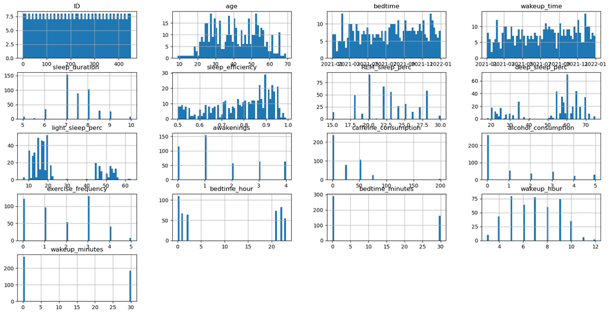

```python
# Onderdeel van EDA-visualisatie: Histogram van elke kolom in de'sleep' dataset. Geeft het aantal waarden van elke kolom weer.
sleep.hist(bins=60, figsize=(20,10))
```

# Is er een verschil tussen geslacht en leeftijd dat de slaapefficiëntie kan beïnvloeden?

U kunt alle waarden uit de leeftijdskolom zien die overeenkomen met het geslacht van het proefpersoon. Dit is nodig om precies te controleren of elke leeftijdswaarde overeenkomt met de overeenkomstige geslachtswaarde.

```python
#Geef de leeftijd en het geslacht weer voor een gedetailleerder en eenvoudiger overzicht.
for index, row in sleep.head(20).iterrows():
    print(str(row["age"]) + " : " + row["gender"])
```

```
65 : Female
69 : Male
40 : Female
40 : Female
57 : Male
36 : Female
27 : Female
53 : Male
41 : Female
11 : Female
50 : Male
55 : Male
30 : Female
28 : Male
36 : Female
32 : Female
21 : Female
40 : Female
43 : Female
52 : Male
```

Het begrijpen van de geslachtsverdeling binnen de dataset is cruciaal voor het analyseren van slaappatronen per geslacht.

```python
#Toon alle waardetellingen van elke geslachtscategorie: 'Male' en 'Female'.
sleep_gender = sleep['gender'] .value_counts()
sleep_gender
```

```
gender
Male      228
Female    224
Name: count, dtype: int64
```

Staafdiagrammen zijn eenvoudig en bieden duidelijke visuele vergelijkingen tussen beide categorieën: Manelijk en vrouwelijk.

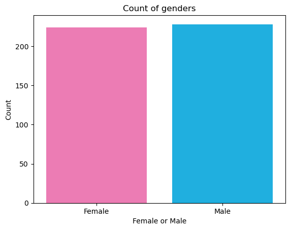

```python
# Staafdiagram om te tellen hoeveel vrouwen en mannen er in het onderzoek zitten.
sns.countplot(sleep, x='gender', palette=['hotpink', 'deepskyblue'])
plt.title('Count of genders')
plt.xlabel('Female or Male')
plt.ylabel('Count')

plt.show()
```

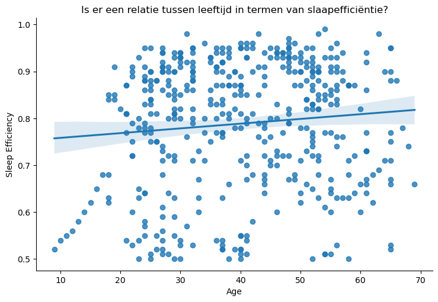

```python
#Deze plot laat ons zien of er een verband bestaat tussen leeftijd en geslacht in termen van slaapefficiëntie.
sns.lmplot(sleep, x='age', y='sleep_efficiency', height=5, aspect=1.5)
plt.title('Is er een relatie tussen leeftijd in termen van slaapefficiëntie?')
plt.xlabel('Age')
plt.ylabel('Sleep Efficiency')

plt.show()
```

# Simple Linear Regression

Simpele lineaire regressie is een statistische methode die wordt gebruikt om een lineair verband te vinden tussen twee continue variabelen. Het doel van simpele lineaire regressie is om de waarden van 𝑎 en b te schatten die de som van het kwadraat van de verschillen tussen de geobserveerde waarden en de door het model voorspelde waarden minimaliseert. Deze code helpt om inzicht te krijgen in hoe leeftijd mogelijk slaapefficiëntie beïnvloedt door het lineaire model te schatten. De output geeft uitgebreide statistische informatie die kan worden gebruikt om te bepalen hoe goed het model past bij de gegevens en of de relatie statistisch significant is.

```python
# Definiëren van de variabelen
# Extractie van de kolom 'leeftijd' en 'slaapefficiëntie' uit de DataFrame en omzetten naar een lijst
x = sleep['age'].tolist()
y = sleep["sleep_efficiency"].tolist()

# Toevoegen van de constante term (intercept) aan de onafhankelijke variabele
x = sm.add_constant(x)

# Uitvoeren van de regressie met behulp van de Ordinary Least Squares (OLS) methode
result = sm.OLS(y, x).fit()

# Afdrukken van de samenvattingstabel
print(result.summary())
```

```
                            OLS Regression Results
==============================================================================
Dep. Variable:                      y   R-squared:                       0.010
Model:                            OLS   Adj. R-squared:                  0.007
Method:                 Least Squares   F-statistic:                     4.396
Date:                Fri, 21 Jun 2024   Prob (F-statistic):             0.0366
Time:                        09:47:34   Log-Likelihood:                 265.67
No. Observations:                 452   AIC:                            -527.3
Df Residuals:                     450   BIC:                            -519.1
Df Model:                           1
Covariance Type:            nonrobust
==============================================================================
                 coef    std err          t      P>|t|      [0.025      0.975]
------------------------------------------------------------------------------
const          0.7482      0.020     36.657      0.000       0.708       0.788
x1             0.0010      0.000      2.097      0.037    6.33e-05       0.002
==============================================================================
Omnibus:                       57.059   Durbin-Watson:                   2.102
Prob(Omnibus):                  0.000   Jarque-Bera (JB):               40.895
Skew:                          -0.627   Prob(JB):                     1.32e-09
Kurtosis:                       2.225   Cond. No.                         137.
==============================================================================

Notes:
[1] Standard Errors assume that the covariance matrix of the errors is correctly specified.
```

# Hoe kan ik mijn R-squared verhogen?

R-squared zit op 0,010. Doel: De R-squared verdubbelde om een lichte verbetering in het verklaringsvermogen van de relatie tussen leeftijd en slaap efficiëntie te tonen.

De code filtert een dataset om alleen gegevens van mensen tussen 20 en 50 jaar te bekijken en maakt vervolgens een scatterplot met een simple lineaire regressielijn om de relatie tussen leeftijd en slaap efficiëntie te visualiseren.

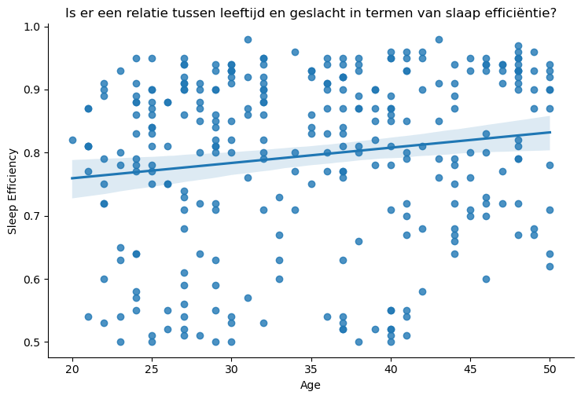

```python
# Filteren van de gegevens om alleen leeftijden tussen 20 en 50 op te nemen
sleep_filtered = sleep[(sleep['age'] >= 20) & (sleep['age'] <= 50)]

# Deze plot laat zien of er een relatie is tussen leeftijd in termen van slaap efficiëntie.
sns.lmplot(data=sleep_filtered, x='age', y='sleep_efficiency', palette=['hotpink', 'deepskyblue'], height=5, aspect=1.5)
plt.title('Is er een relatie tussen leeftijd en geslacht in termen van slaap efficiëntie?')
plt.xlabel('Age')
plt.ylabel('Sleep Efficiency')

plt.show()
```

De boxplot laat zien dat de slaap efficiëntie in de dataset voornamelijk varieert tussen 0,7 en 1,0, met een mediane waarde van 0,8. Dit geeft aan dat de meeste mensen een relatief hoge slaap efficiëntie hebben.

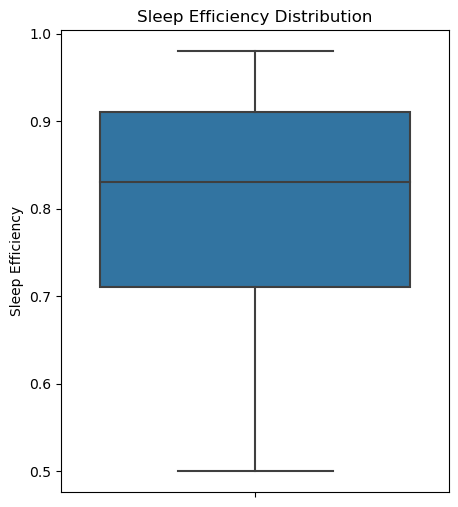

```python
# Een boxplot maken om de verdeling van slaap efficiëntie naar leeftijd en geslacht te laten zien.
plt.figure(figsize=(5, 6))
sns.boxplot(data=sleep_filtered, y='sleep_efficiency', showfliers=False)
plt.title('Sleep Efficiency Distribution')
plt.ylabel('Sleep Efficiency')

plt.show()
```

Als je kunt zin de R-kwadraat waarde verdubbelde van 0,010 naar 0,020, wat duidt op een lichte verbetering in het verklaringsvermogen van de relatie tussen leeftijd en slaap efficiëntie. Ondanks deze verdubbeling blijft de relatie zwak, aangezien slechts 2% van de variatie in slaap efficiëntie wordt verklaard door leeftijd.

```python
# Definiëren van de variabelen
# Extractie van de kolom 'leeftijd' en 'slaapefficiëntie' uit de DataFrame en omzetten naar een lijst
x = sleep_filtered['age'].tolist()
y = sleep_filtered["sleep_efficiency"].tolist()

# Toevoegen van de constante term (intercept) aan de onafhankelijke variabele
x = sm.add_constant(x)

# Uitvoeren van de regressie met behulp van de Ordinary Least Squares (OLS) methode
result = sm.OLS(y, x).fit()

# Afdrukken van de samenvattingstabel
print(result.summary())
```

```
                            OLS Regression Results
==============================================================================
Dep. Variable:                      y   R-squared:                       0.023
Model:                            OLS   Adj. R-squared:                  0.020
Method:                 Least Squares   F-statistic:                     7.218
Date:                Fri, 21 Jun 2024   Prob (F-statistic):            0.00761
Time:                        09:47:35   Log-Likelihood:                 180.01
No. Observations:                 309   AIC:                            -356.0
Df Residuals:                     307   BIC:                            -348.5
Df Model:                           1
Covariance Type:            nonrobust
==============================================================================
                 coef    std err          t      P>|t|      [0.025      0.975]
------------------------------------------------------------------------------
const          0.7109      0.032     21.885      0.000       0.647       0.775
x1             0.0024      0.001      2.687      0.008       0.001       0.004
==============================================================================
Omnibus:                       34.837   Durbin-Watson:                   1.886
Prob(Omnibus):                  0.000   Jarque-Bera (JB):               34.551
Skew:                          -0.757   Prob(JB):                     3.14e-08
Kurtosis:                       2.376   Cond. No.                         152.
==============================================================================

Notes:
[1] Standard Errors assume that the covariance matrix of the errors is correctly specified.
```

# Conclusie

De verbetering van de R-kwadraat waarde van 0,010 naar 0,020 in de lineaire regressie duidt op een iets beter verklaringsvermogen van de relatie tussen leeftijd en slaap efficiëntie. Ondanks deze verbetering blijft de relatie zwak, aangezien slechts 2% van de variatie in slaap efficiëntie wordt verklaard door leeftijd. Dit suggereert dat andere factoren waarschijnlijk een grotere invloed hebben op slaap efficiëntie en dat verdere analyse met extra variabelen nodig is voor een vollediger inzicht.

De boxplot laat zien dat de slaap efficiëntie in de dataset voornamelijk varieert tussen 0,7 en 1,0, met een mediane waarde van 0,8. Dit geeft aan dat de meeste mensen een relatief hoge slaap efficiëntie hebben. Deze bevinding ondersteunt de conclusie uit de lineaire regressie dat leeftijd slechts een zwakke verklaring biedt voor de variatie in slaap efficiëntie (R-kwadraat van 0,020). Dit suggereert dat andere factoren, naast leeftijd, belangrijk zijn voor het begrijpen van slaap efficiëntie. Verdere analyse met extra variabelen is daarom noodzakelijk om een vollediger beeld te krijgen.

Scatterplot met een lineaire regressielijn voor elk geslacht. De parameter hue='gender' kleurt de gegevenspunten verschillend voor beide geslachten en creëert aparte regressielijnen.

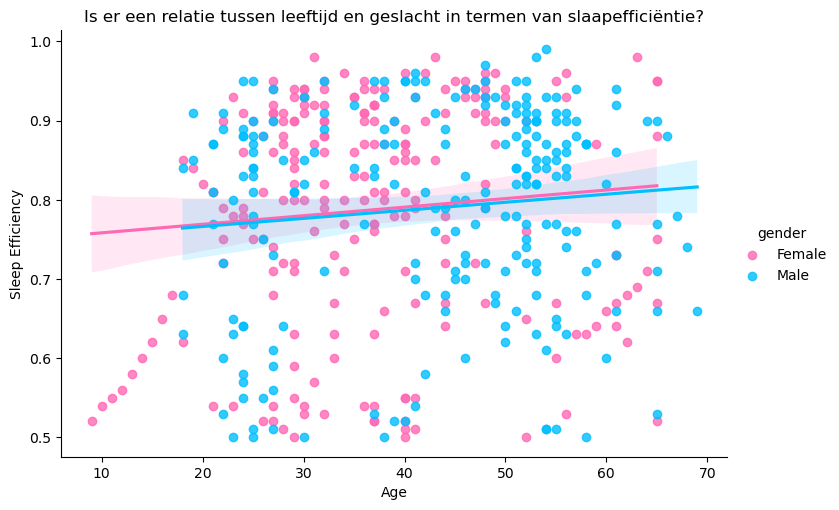

```python
#Deze plot laat ons zien of er een verband bestaat tussen leeftijd en geslacht in termen van slaapefficiëntie.
sns.lmplot(sleep, x='age', y='sleep_efficiency', hue='gender', palette=['hotpink', 'deepskyblue'], height=5, aspect=1.5)
plt.title('Is er een relatie tussen leeftijd en geslacht in termen van slaapefficiëntie?')
plt.xlabel('Age')
plt.ylabel('Sleep Efficiency')

plt.show()
```

# Multiple Linear Regression

Multiple Linear Regression is een statistische techniek die wordt gebruikt om de relatie te modelleren tussen één afhankelijke variabele en twee of meer onafhankelijke variabelen. Het doel is om de waarde van de afhankelijke variabele te voorspellen op basis van de waarden van de onafhankelijke variabelen. Het model gaat uit van een lineaire relatie tussen de afhankelijke en onafhankelijke variabelen. Deze code zet eerst de 'gender' kolom van de dataset om van categorische waarden ('Male' en 'Female') naar numerieke waarden (0 voor 'Male' en 1 voor 'Female'), omdat regressiemodellen numerieke input vereisen. Vervolgens worden de onafhankelijke variabelen 'age' en 'gender' geselecteerd en wordt de afhankelijke variabele 'sleep_efficiency' gedefinieerd

```python
## Omzetten van de 'gender' kolom naar numerieke waarden.
# Dit wordt gedaan omdat regressiemodellen in statsmodels numerieke input vereisen.
# Het omzetten van categorische gegevens (Man, Vrouw) naar numerieke waarden (0, 1) stelt het model in staat om deze correct te verwerken.
sleep['gender'] = sleep[ 'gender'].map({'Male': 0, 'Female': 1})

## Definiëren van de variabelen
X = sleep[['age', 'gender']]
y = sleep['sleep_efficiency']

# Toevoegen van de constante term (intercept) aan de onafhankelijke variabelen
X = sm.add_constant(X)

# Uitvoeren van de regressie en het fitten van het model
result = sm.OLS(y, X).fit()

# Afdrukken van de samenvattingstabel
print(result.summary())
```

```
                            OLS Regression Results
==============================================================================
Dep. Variable:       sleep_efficiency   R-squared:                       0.010
Model:                            OLS   Adj. R-squared:                  0.005
Method:                 Least Squares   F-statistic:                     2.241
Date:                Fri, 21 Jun 2024   Prob (F-statistic):              0.108
Time:                        09:47:36   Log-Likelihood:                 265.71
No. Observations:                 452   AIC:                            -525.4
Df Residuals:                     449   BIC:                            -513.1
Df Model:                           2
Covariance Type:            nonrobust
==============================================================================
                 coef    std err          t      P>|t|      [0.025      0.975]
------------------------------------------------------------------------------
const          0.7447      0.023     31.843      0.000       0.699       0.791
age            0.0010      0.000      2.106      0.036       7e-05       0.002
gender         0.0040      0.013      0.307      0.759      -0.022       0.030
==============================================================================
Omnibus:                       56.985   Durbin-Watson:                   2.099
Prob(Omnibus):                  0.000   Jarque-Bera (JB):               41.182
Skew:                          -0.630   Prob(JB):                     1.14e-09
Kurtosis:                       2.227   Cond. No.                         164.
==============================================================================

Notes:
[1] Standard Errors assume that the covariance matrix of the errors is correctly specified.
```

# Hoe kan ik mijn R-squared verhogen?

Scatterplot maken met een lineaire regressielijn voor elke geslachtsgroep.De 'hue'-parameter zorgt ervoor dat de datapunten verschillend worden gekleurd op basis van geslacht.

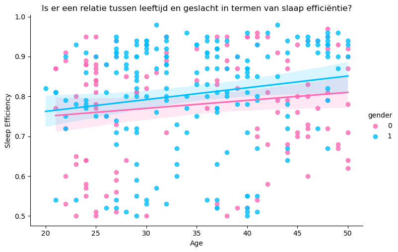

```python
# Filteren van de gegevens om alleen leeftijden tussen 20 en 50 op te nemen
sleep_filtered1 = sleep[(sleep['age'] >= 20) & (sleep['age'] <= 50)]

# Deze plot laat zien of er een relatie is tussen leeftijd en geslacht in termen van slaap efficiëntie.
sns.lmplot(data=sleep_filtered1, x='age', y='sleep_efficiency', hue='gender', palette=['hotpink', 'deepskyblue'], height=5, aspect=1.5)
plt.title('Is er een relatie tussen leeftijd en geslacht in termen van slaap efficiëntie?')
plt.xlabel('Age')
plt.ylabel('Sleep Efficiency')

plt.show()
```

Deze boxplot toont de verdeling van slaap efficiëntie voor verschillende geslachtsgroepen. Door de boxplot te bekijken, kunnen we snel zien hoe de slaap efficiëntie varieert tussen mannen en vrouwen.

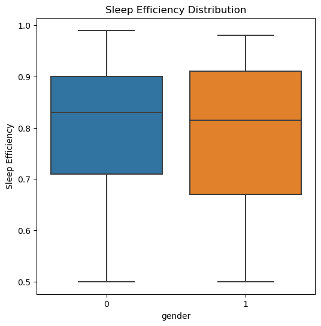

```python
# Een boxplot maken om de verdeling van slaap efficiëntie te tonen per leeftijd en geslacht
plt.figure(figsize=(6, 6))
sns.boxplot(data=sleep, x= 'gender', y='sleep_efficiency', showfliers=False)
plt.title('Sleep Efficiency Distribution')
plt.ylabel('Sleep Efficiency')

plt.show()
```

De boxplot laat zien dat de slaap efficiëntie vergelijkbaar is voor beide geslachten, met mediane waarden rond 0,8 en vergelijkbare interkwartielafstanden (IQR). De verdelingen voor beide geslachten variëren van ongeveer 0,5 tot 1,0, wat aangeeft dat er geen significante uitschieters zijn op basis van geslacht.

```python
# Definiëren van de variabelen
# Extractie van de kolom 'leeftijd' en 'slaapefficiëntie' uit de DataFrame en omzetten naar een lijst
x = sleep_filtered['age'].tolist()
y = sleep_filtered["sleep_efficiency"].tolist()

# Toevoegen van de constante term (intercept) aan de onafhankelijke variabele
x = sm.add_constant(x)

# Uitvoeren van de regressie met behulp van de Ordinary Least Squares (OLS) methode
result = sm.OLS(y, x).fit()

# Afdrukken van de samenvattingstabel
print(result.summary())
```

```
                            OLS Regression Results
==============================================================================
Dep. Variable:                      y   R-squared:                       0.023
Model:                            OLS   Adj. R-squared:                  0.020
Method:                 Least Squares   F-statistic:                     7.218
Date:                Fri, 21 Jun 2024   Prob (F-statistic):            0.00761
Time:                        09:47:36   Log-Likelihood:                 180.01
No. Observations:                 309   AIC:                            -356.0
Df Residuals:                     307   BIC:                            -348.5
Df Model:                           1
Covariance Type:            nonrobust
==============================================================================
                 coef    std err          t      P>|t|      [0.025      0.975]
------------------------------------------------------------------------------
const          0.7109      0.032     21.885      0.000       0.647       0.775
x1             0.0024      0.001      2.687      0.008       0.001       0.004
==============================================================================
Omnibus:                       34.837   Durbin-Watson:                   1.886
Prob(Omnibus):                  0.000   Jarque-Bera (JB):               34.551
Skew:                          -0.757   Prob(JB):                     3.14e-08
Kurtosis:                       2.376   Cond. No.                         152.
==============================================================================

Notes:
[1] Standard Errors assume that the covariance matrix of the errors is correctly specified.
```

# Conclusie

De boxplot laat zien dat de slaap efficiëntie vergelijkbaar is voor beide geslachten, met mediane waarden rond 0,8 en vergelijkbare interkwartielafstanden (IQR). De verdelingen voor beide geslachten variëren van ongeveer 0,5 tot 1,0, wat aangeeft dat er geen significante uitschieters zijn op basis van geslacht. Dit ondersteunt de conclusie uit de regressieanalyse dat geslacht geen significante invloed heeft op slaap efficiëntie.

# Wat is de voorkeurstijd om te gaan slapen/ontwaaktijd tussen de deelnemers?

Eerst inspecteren we de telling van de bedtijduren om te weten welk uur de meeste tellingen heeft. Wij hebben eenvoudig een overzicht van de tellingen en de uren gedaan.

```python
sleep['bedtime_hour']
```

```
0       1
1       2
2      21
3       2
4       1
       ..
447    22
448    21
449    23
450    21
451     2
Name: bedtime_hour, Length: 452, dtype: int32
```

Vervolgens vatten we deze telling samen met de functie 'value_counts()'. Dit geeft ons een samenvatting van alle waarden en hun corresponderende aantal.

```python
sleep['bedtime_hour'].value_counts()
```

```
bedtime_hour
0     110
22     83
21     73
1      67
2      64
23     55
Name: count, dtype: int64
```

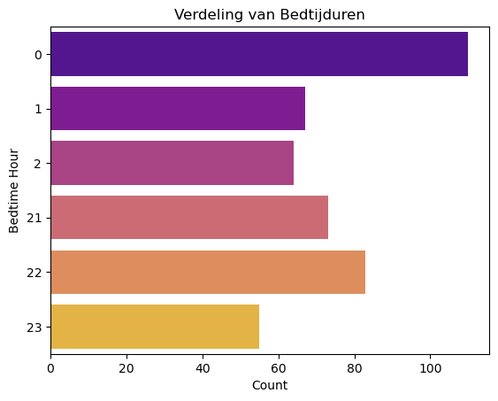

```python
# Vertical countplot with 'bedtime_hour' on the y-axis
sns.countplot(data= sleep, y="bedtime_hour", palette="plasma")

#Adding tittles and labels
plt.title('Verdeling van Bedtijduren')
plt.xlabel('Count')
plt.ylabel('Bedtime Hour')

#Displays the plot
plt.show()
```

Meestal gaan mensen het liefst om 12.00 uur 's avonds slapen.

Deze keer doen we hetzelfde proces, maar een andere variabele: 'Wektijduren'. We geven het volledige overzicht weer met elke waarde en hun totale aantal.

```python
sleep['wakeup_hour']
```

```
0       7
1       9
2       5
3       8
4       9
       ..
447     5
448     3
449     7
450     4
451    10
Name: wakeup_hour, Length: 452, dtype: int32
```

```python
#We tonen het overzicht met alle waarden en hun bijbehorende tellingen.
wakeup_hours = sleep['wakeup_hour'].value_counts()
wakeup_hours
```

```
wakeup_hour
5     80
7     78
9     74
6     64
8     60
4     43
10    35
3     10
11     6
12     2
Name: count, dtype: int64
```

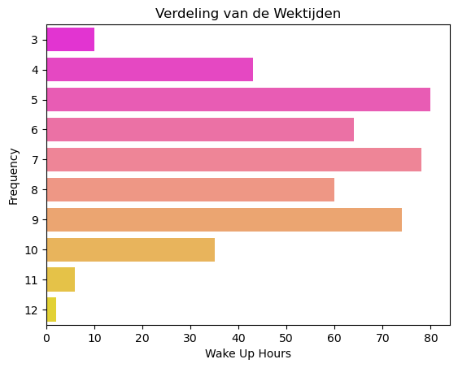

```python
sns.countplot(data= sleep, y="wakeup_hour", palette="spring")
# Adding titles and labels
plt.title('Verdeling van de Wektijden')
plt.xlabel('Wake Up Hours')
plt.ylabel('Frequency')
```

Meestal worden de meeste mensen om 5 uur 's ochtends wakker.

# Beïnvloeden andere stoffen (bijv. alcohol, koffie, rokers...) slaappatronen?

Een boxplot helpt om medianen te vergelijken en spreiding en outliers te identificeren, hier zonder outliers voor een duidelijker beeld.

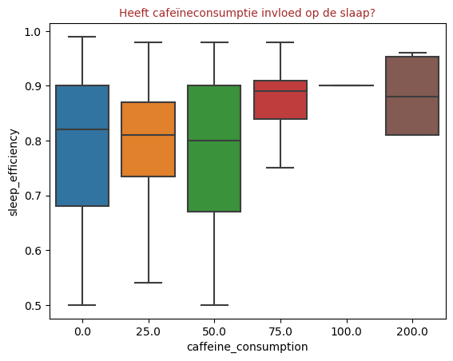

```python
# Boxplot toont de relatie tussen cafeïneconsumptie en slaapefficiëntie.
sns.boxplot(sleep,x ='caffeine_consumption', y= 'sleep_efficiency',showfliers=False)
plt.title("Heeft cafeïneconsumptie invloed op de slaap?", color="brown",fontsize=10)

plt.show()
```

Deze visualisatie onderzoekt of er een verband is tussen alcoholgebruik en de hoeveelheid lichte slaap, wat nuttig is voor slaaponderzoek.

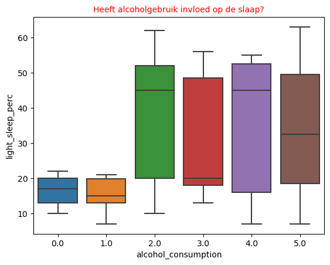

```python
# Boxplot toont de relatie tussen alcoholconsumptie en het percentage lichte slaap.
sns.boxplot(sleep,x ='alcohol_consumption', y= 'light_sleep_perc',showfliers=False)
plt.title("Heeft alcoholgebruik invloed op de slaap?", color="red",fontsize=10)

plt.show()
```

Onder alcoholconsumptie kunnen we stellen dat als je meer alcohol drinkt, je een licht slaappercentage hebt dan de mensen die geen alcohol dronken.

Deze plot analyseert hoe roken slaapefficiëntie kan beïnvloeden, wat inzichten kan bieden voor gezondheidsvoorlichting.

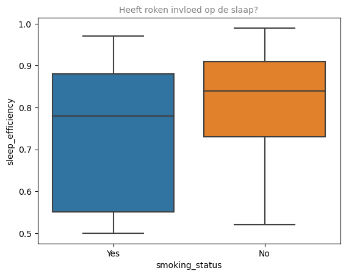

```python
# Boxplot toont de invloed van roken op slaapefficiëntie.
sns.boxplot(sleep, x ='smoking_status', y= 'sleep_efficiency',showfliers=False)
plt.title("Heeft roken invloed op de slaap?", color="grey",fontsize=10)

plt.show()
```

Ja, het beïnvloedt de slaapefficiëntie. Als je een niet-roker bent, zult je een betere slaapkwaliteit hebben.

Dit onderzoekt de invloed van fysieke activiteit op de kwaliteit van diepe slaap, cruciaal voor herstelprocessen.

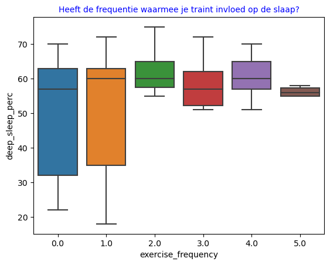

```python
# Boxplot onderzoekt het effect van trainingsfrequentie op het percentage diepe slaap.
sns.boxplot(sleep, x ='exercise_frequency', y= 'deep_sleep_perc',showfliers=False)
plt.title("Heeft de frequentie waarmee je traint invloed op de slaap?", color="blue",fontsize=10)

plt.show()
```

Door te oefenen kunnen we zien dat als u gematigde oefeningen doet, u een diepere slaap kunt hebben dan degenen die niet veel of te veel oefenen.

# Beïnvloedt het aantal keren dat men wakker wordt de slaapefficiëntie?

Bereken de gemiddelde slaapefficiëntie per aantal keer ontwaken. Reden: Door te groeperen op basis van het aantal ontwakingen, verkrijgen we inzicht in de invloed van het aantal keer wakker worden op de slaapefficiëntie

```python
mean_sleep = sleep.groupby('awakenings')['sleep_efficiency'].mean().reset_index()

# De kolommen hernoemen voor de duidelijkheid
mean_sleep.columns = ['Number of Awakenings', 'Average Sleep Efficiency']

# Weergave van de gegroepeerde gegevens
print(mean_sleep)
```

```
   Number of Awakenings  Average Sleep Efficiency
0                   0.0                  0.891304
1                   1.0                  0.821039
2                   2.0                  0.693509
3                   3.0                  0.691746
4                   4.0                  0.706984
```

Beschrijvende statistieken voor 'awakenings' en 'sleep_efficiency' geven een overzicht van deze variabelen.

```python
deep_awake= sleep[['awakenings', 'sleep_efficiency']].describe()
deep_awake
```

|  | awakenings | sleep_efficiency |
| --- | --- | --- |
| count | 452.000000 | 452.000000 |
| mean | 1.568584 | 0.788916 |
| std | 1.368698 | 0.135237 |
| min | 0.000000 | 0.500000 |
| 25% | 0.000000 | 0.697500 |
| 50% | 1.000000 | 0.820000 |
| 75% | 3.000000 | 0.900000 |
| max | 4.000000 | 0.990000 |

De code genereert een grafiek die het verband illustreert tussen hoe vaak iemand wakker wordt en de gemiddelde slaapefficiëntie. Het stelt de grootte van de grafiek in, tekent een lijnplot met punten, en voegt titels en labels toe voor duidelijkheid. Ten slotte toont het de grafiek met plt.show().

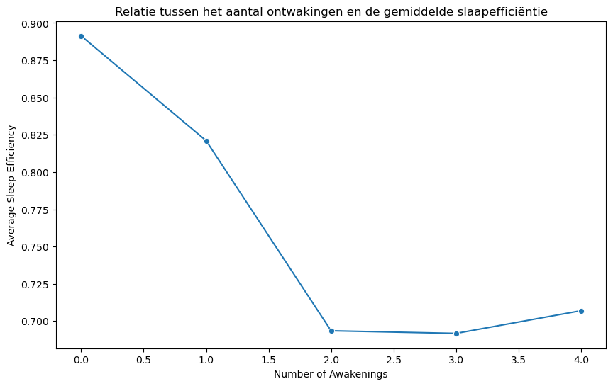

```python
# Lijngrafiek die het verband toont tussen het aantal keer wakker worden en de gemiddelde slaapefficiëntie.
plt.figure(figsize=(10, 6))  # Sets the figure size
sns.lineplot(data=mean_sleep, x='Number of Awakenings', y='Average Sleep Efficiency', marker='o')  # Line plot with markers

# Titels en labels toevoegen voor de duidelijkheid
plt.title('Relatie tussen het aantal ontwakingen en de gemiddelde slaapefficiëntie')
plt.xlabel('Number of Awakenings')
plt.ylabel('Average Sleep Efficiency')

# Toon de plot
plt.show()
```

Zoals je kunt zien, beïnvloedt het aantal keren dat we wakker worden de slaapefficiëntie bij elk individu. Concluderend heeft het aantal keren dat we wakker worden tijdens onze slaap invloed op onze slaap.

# Conclusie / Advies

Conclusie: Het primaire doel van het slaap efficiëntie project was om de kwaliteit van slaap onder verschillende individuen te begrijpen en de factoren te identificeren die de slaap efficiëntie beïnvloeden. Na het analyseren van de gegevens zijn er verschillende belangrijke bevindingen naar voren gekomen:

- Zwakke Relatie Tussen Leeftijd en Slaap Efficiëntie:

De R-kwadraat waarde verbeterde van 0,010 naar 0,020, wat wijst op een iets beter verklarend vermogen van de relatie tussen leeftijd en slaap efficiëntie. Echter, deze relatie blijft zwak, aangezien slechts 2% van de variatie in slaap efficiëntie kan worden verklaard door leeftijd. Dit suggereert dat andere factoren waarschijnlijk een grotere invloed hebben op slaap efficiëntie.

- Verdeling van Slaap Efficiëntie:

De boxplot-analyse onthulde dat slaap efficiëntie in de dataset voornamelijk varieert tussen 0,7 en 1,0, met een mediane waarde van 0,8. Dit geeft aan dat de meeste individuen een relatief hoge slaap efficiëntie hebben. Deze bevinding ondersteunt de conclusie dat leeftijd een zwak verklarend vermogen heeft voor de variatie in slaap efficiëntie en dat andere factoren waarschijnlijk belangrijker zijn.

- Impact van Andere Variabelen:

Verdere analyse, inclusief de impact van geslacht, middelengebruik (bijv. alcohol, koffie, roken), frequentie van lichaamsbeweging en het aantal nachtelijke ontwakingen, is essentieel om een volledig begrip te krijgen van wat slaap efficiëntie beïnvloedt. De analyse toonde aan dat deze variabelen mogelijk significante effecten hebben op slaappatronen en efficiëntie.

Advies: Om de slaap efficiëntie en de algehele slaapkwaliteit te verbeteren, overweeg de volgende aanbevelingen op basis van de analyse:

- Focus op Meerdere Factoren:

Aangezien leeftijd alleen niet significant de variaties in slaap efficiëntie verklaart, is het cruciaal om meerdere factoren in overweging te nemen, waaronder leefstijlkeuzes, omgevingsinvloeden en gedragsgewoonten.

- Monitor en Pas Leefgewoonten Aan:

Let op het gebruik van stoffen zoals alcohol en cafeïne, evenals rookgewoonten. Het verminderen van de inname, vooral vlak voor het slapengaan, kan de slaapkwaliteit verbeteren.

- Handhaaf een Regelmatige Oefenroutine:

Regelmatige lichaamsbeweging heeft aangetoond een positieve invloed te hebben op diepe slaap efficiëntie. Integreer consequent lichaamsbeweging in je dagelijkse routine om de slaapkwaliteit te verbeteren.

- Minimaliseer Onderbrekingen Tijdens de Slaap:

Probeer het aantal nachtelijke ontwakingen te verminderen. Het creëren van een comfortabele slaapomgeving, het verminderen van geluid en licht, en het beheersen van stressniveaus kunnen helpen om een meer ononderbroken slaap te bereiken.

- Gepersonaliseerd Slaapschema:

Het begrijpen van individuele slaappatronen en -voorkeuren is cruciaal. Het aannemen van een slaapschema dat aansluit bij je natuurlijke slaap-waakcyclus kan de slaap efficiëntie verbeteren.

- Verdere Analyse en Monitoring:

Blijf slaappatronen monitoren en voer verdere analyses uit om eventuele extra variabelen te identificeren die de slaap efficiëntie beïnvloeden. Hulpmiddelen zoals slaaptrackers kunnen waardevolle inzichten bieden in slaapgewoonten en verbeterpunten.

Door rekening te houden met deze factoren en weloverwogen aanpassingen te maken, kunnen individuen werken aan het bereiken van een betere slaap efficiëntie en algehele slaapkwaliteit.

# Bronnen

https://www.kaggle.com/datasets/equilibriumm/sleep-efficiency

https://realpython.com/python-for-data-analysis/

https://app.datacamp.com/learn/career-tracks/data-analyst-with-python

https://www.w3schools.com/python/python_modules.asp

https://www.mathworks.com/help/matlab/ref/barh.html?requestedDomain=

https://statsandr.com/blog/multiple-linear-regression-made-simple/

https://moderndive.com/5-regression.html

https://www.statsmodels.org/dev/generated/statsmodels.regression.linear_model.OLS.html

https://stichtingfontys.sharepoint.com/:p:/r/sites/BusinessSemester2ensemester32024VJ-Semester3Business/Gedeelde%20documenten/Semester%203%20Business/Lessen/Week_14_sem3.pptx?d=wb3b60876a08944889558ee04fb7057a1&csf=1&web=1&e=iEq2Kf&wdOrigin=TEAMS-MAGLEV.teams_ns.rwc&wdExp=TEAMS-TREATMENT&wdhostclicktime=1718954854363&web=1